# Generalized Mixed Models

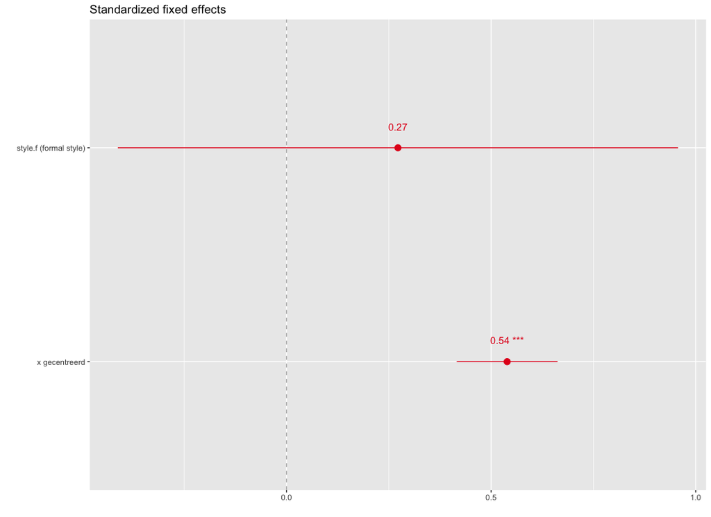

```r
# Plot standardised fixed effects
sjp.lmer(fit5c, type = "fe.std")
```

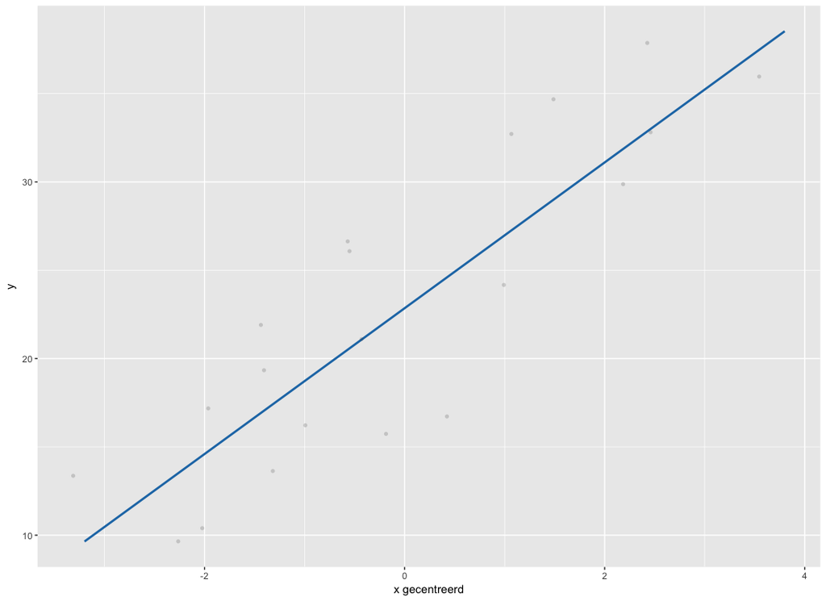

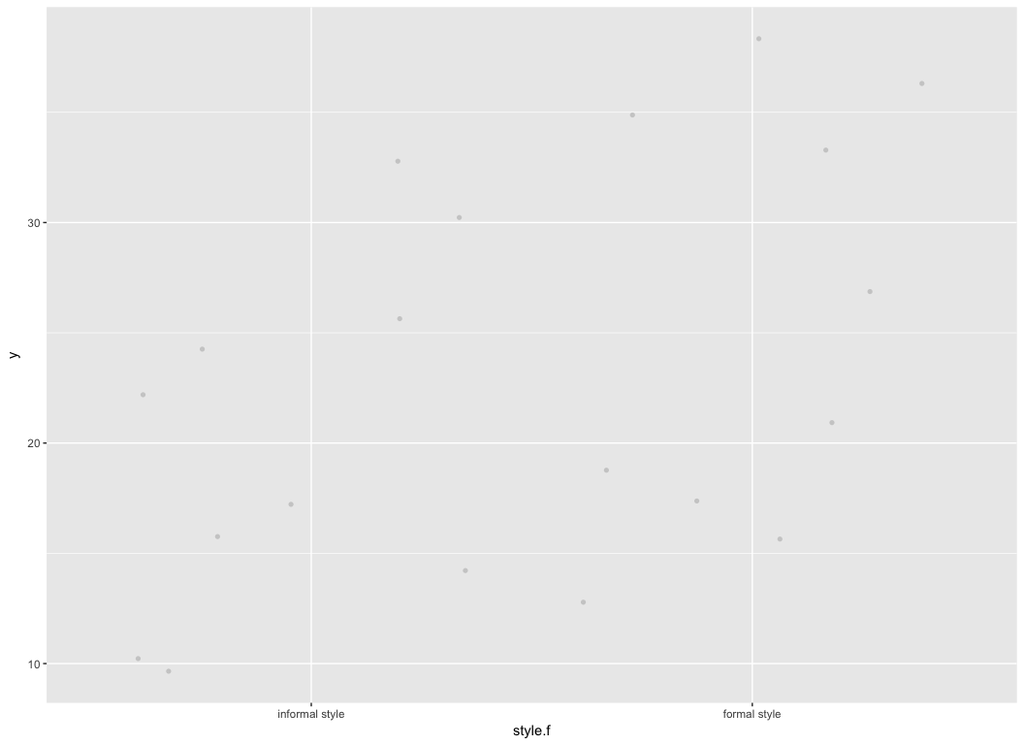

```r
# plot fixed effects slopes
sjp.lmer(fit5c, type = "fe.slope", vars = c("xc", "style.f"))
```

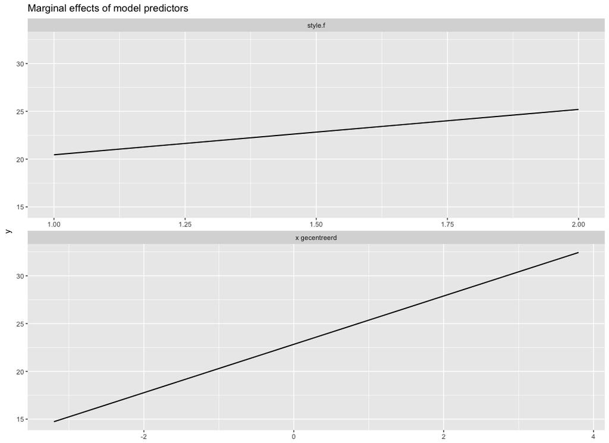

```r
# plot effects
sjp.lmer(fit5c, type = "eff")
```

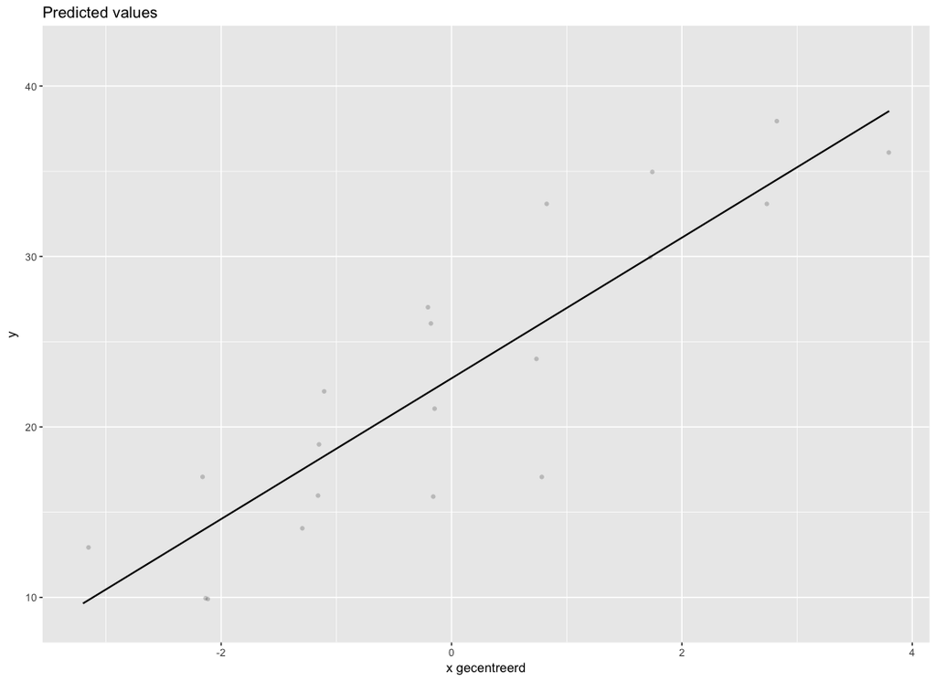

```r
# plot effects
sjp.lmer(fit5c, type = "pred", vars = "xc")
```

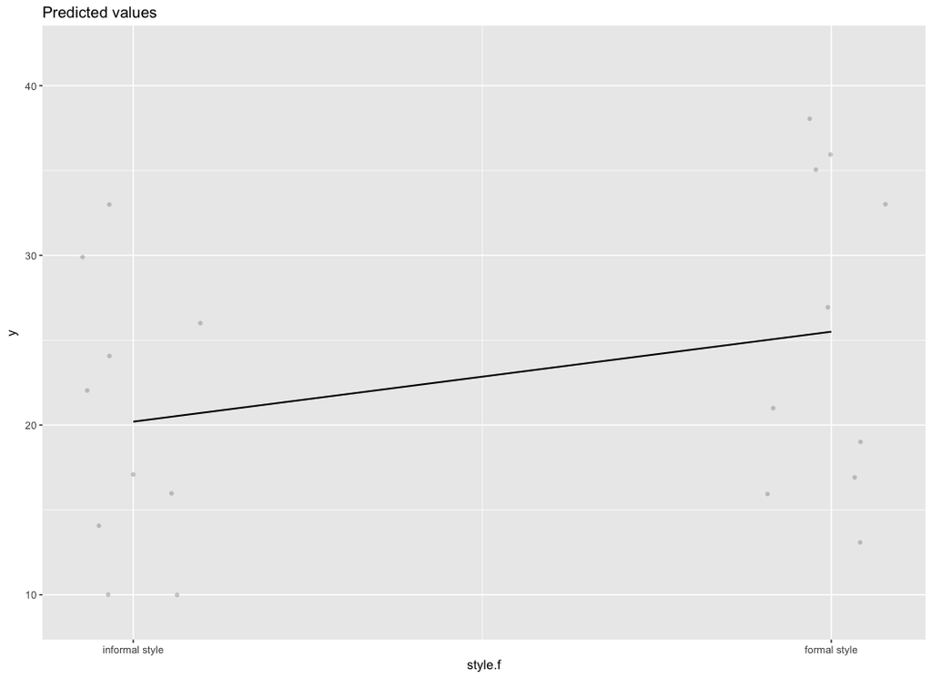

```r
sjp.lmer(fit5c, type = "pred", vars = "style.f")
```

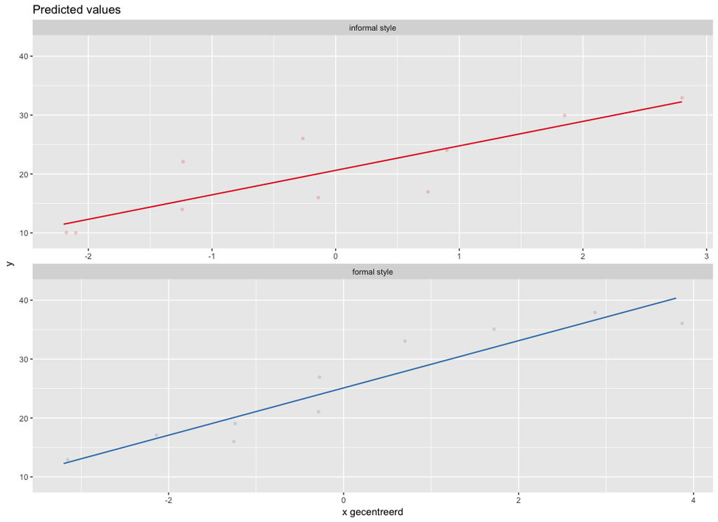

```r
# plot effects
sjp.lmer(fit5c, type = "pred", vars = c("xc", "style.f"))
```

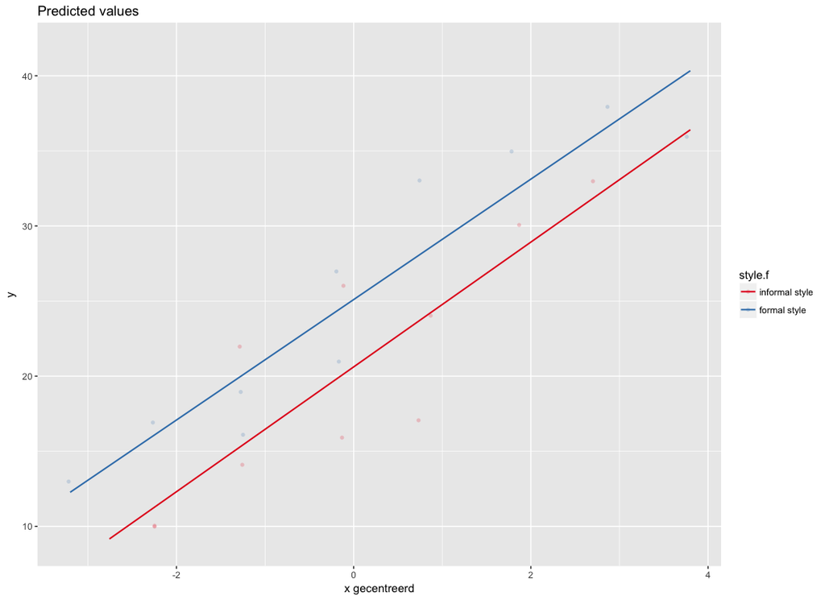

```r
# plot effects
sjp.lmer(fit5c, type = "pred",
         facet.grid = FALSE,
         vars = c("xc", "style.f"))
```

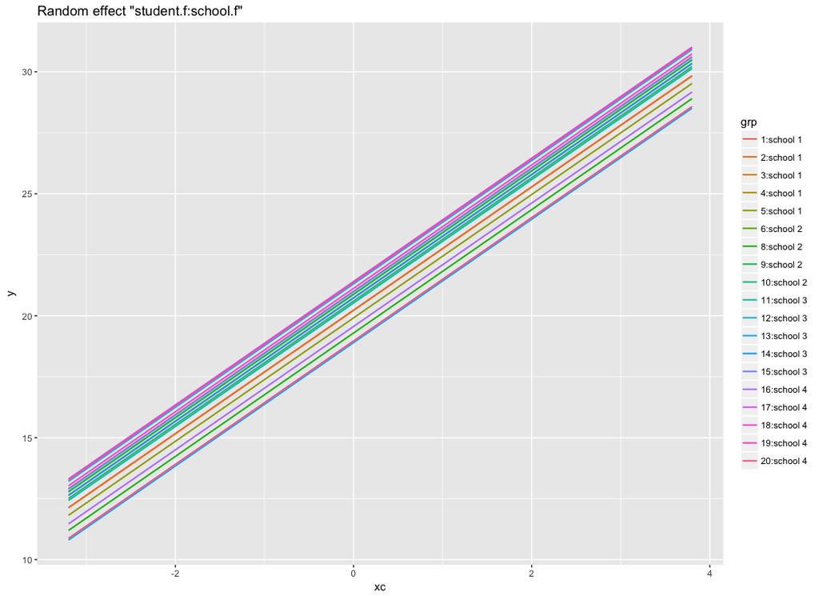

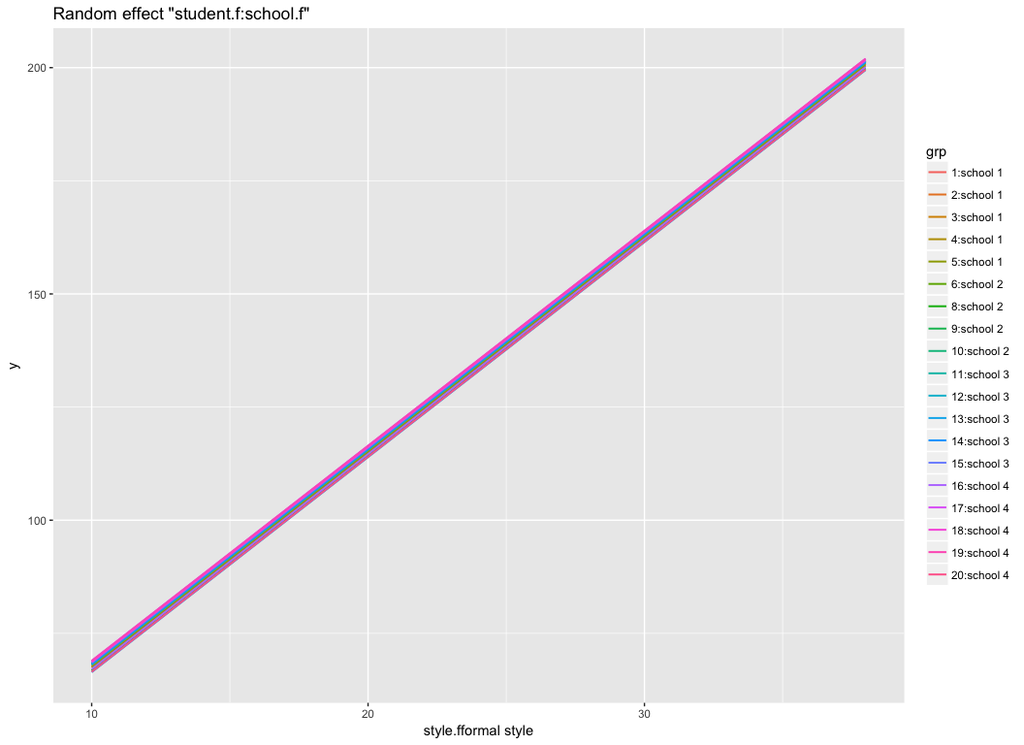

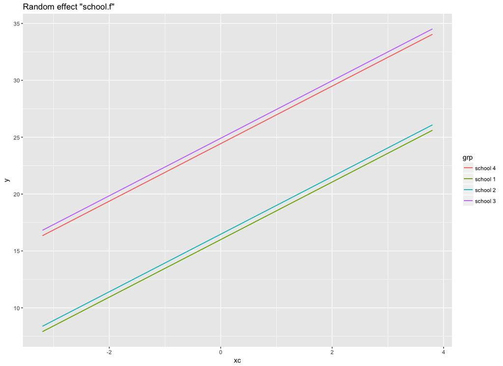

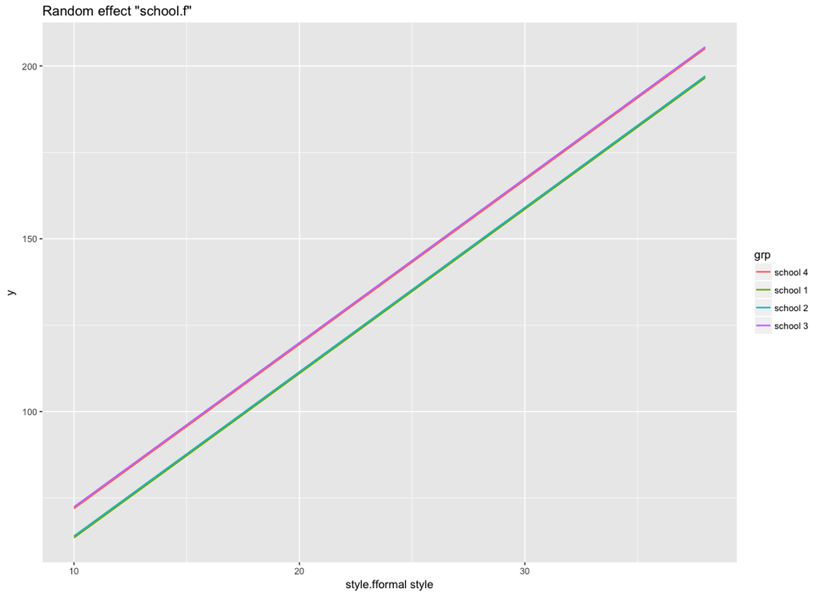

```r
# plot fixed effects depending on group levels
sjp.lmer(fit5c, type = "ri.slope")
```

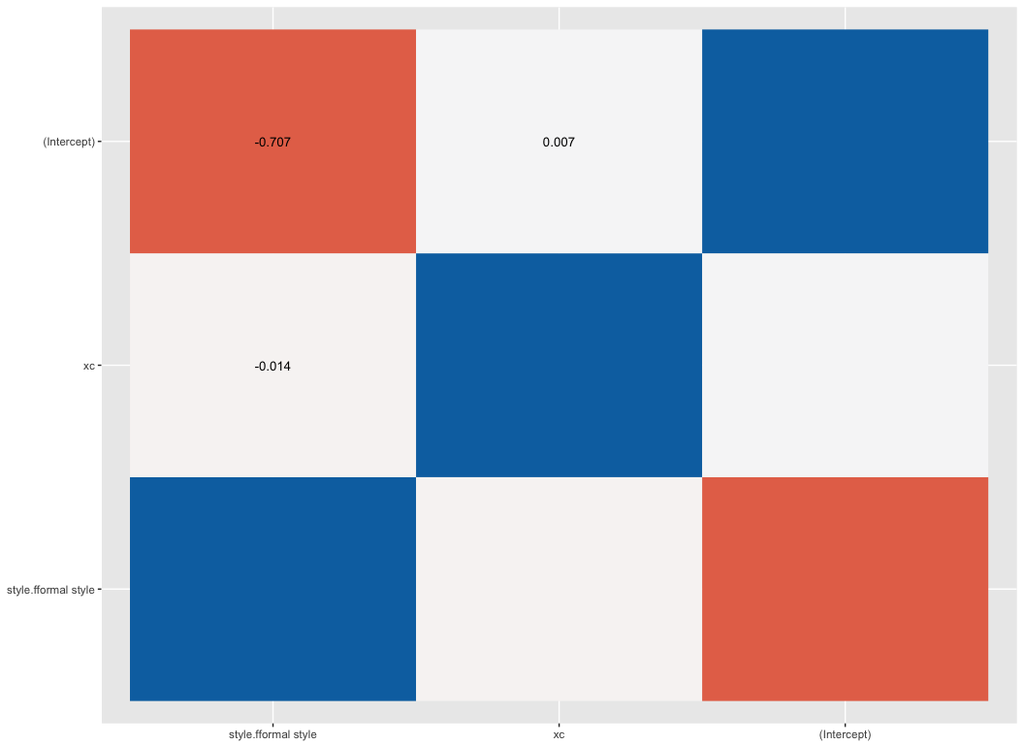

```r
# plot fixed effects correlation matrix
sjp.lmer(fit5c, type = "fe.cor")
```

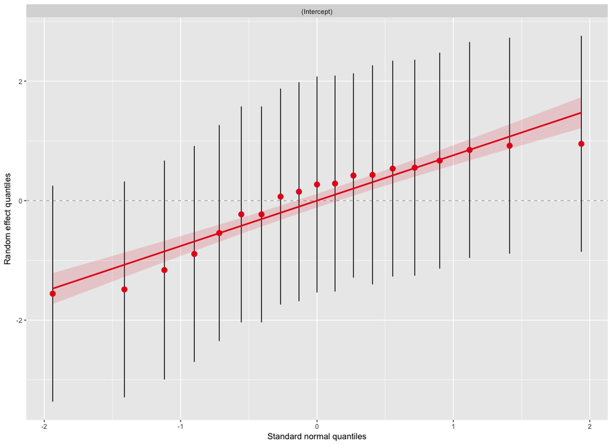

```r
# plot qq-plot of random effects
sjp.lmer(fit5c, type = "re.qq")
```

# 4 Random intercepts & slopes

Random intercepts & slopes

## 4.1 Assignment

### 4.1.1 Teaching style

- Try to see whether teaching style explains slope variance of schools.
- Our dataset is too small!

## 4.2 Solution

### 4.2.1 Teaching style

```r
# Add teaching style as a random slope
fit5d <- lmer(y ~ xc + style.f + (style.f |school.f/student.f) ,data = df)
summary(fit5d)
```

```r
# This does work
fit5d <- lmer(y ~ xc  + (xc |school.f) ,data = df)
summary(fit5d)
```

```
Linear mixed model fit by REML
t-tests use  Satterthwaite approximations to degrees of freedom ['lmerMod']
Formula: y ~ xc + (xc | school.f)
   Data: df

REML criterion at convergence: 87.8

Scaled residuals:
    Min      1Q  Median      3Q     Max
-1.7989 -0.3788  0.2166  0.6738  1.1152

Random effects:
 Groups   Name        Variance  Std.Dev. Corr
 school.f (Intercept) 3.214e+01 5.66915
          xc          8.153e-04 0.02855  -1.00
 Residual             2.714e+00 1.64733
Number of obs: 20, groups:  school.f, 4

Fixed effects:
            Estimate Std. Error      df t value Pr(>|t|)
(Intercept)  22.8784     2.8584  2.9170   8.004   0.0045 **
xc            2.5018     0.2883 15.5630   8.678 2.35e-07 ***
---
Signif. codes:  0 '***' 0.001 '**' 0.01 '*' 0.05 '.' 0.1 ' ' 1

Correlation of Fixed Effects:
   (Intr)
xc -0.050
```

[^1]: Importing SPSS files into R can sometimes lead to strange behaviour, because SPSS assigns both *variable* and *value* labels, which most software packages cannot handle. If you can’t get rid of the labels, use `rio::export(df,"filename.ext")` and set `.ext` to `.csv` or `.xlsx`, then reload the file using `df <- rio::import("filename.ext")`